# Retail forecasting project

Yunzhi Chen 32051018

2023-05-21

```r
library(tidyverse)
library(fpp3)
library(patchwork)
library(fable)
library(lubridate)
```

```r
# Use your student ID as the seed
set.seed(32051018)
myseries <- aus_retail %>%
  # Remove discontinued series
  filter(!(`Series ID` %in% c("A3349561R","A3349883F","A3349499L","A3349902A",
                        "A3349588R","A3349763L","A3349372C","A3349450X",
                        "A3349679W","A3349378T","A3349767W","A3349451A"))) %>%
  # Select a series at random
  filter(`Series ID` == sample(`Series ID`,1))
```

# Statistical features

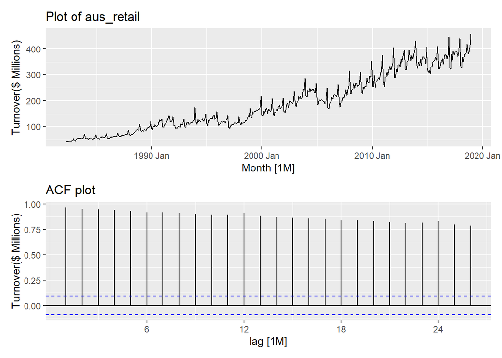

```r
p1 <- myseries %>%
  autoplot(Turnover) +
  labs(title = "Plot of aus_retail",
       y = "Turnover($ Millions)")

p2 <- myseries %>%
   ACF(Turnover) %>%
   autoplot() +
   labs(title = "ACF plot",
        y = "Turnover($ Millions)")

p1/p2
```

From the graph of my Australian retail series, we can see in general, the turnover of Australian retail has an increasing trend. The series appears to have a seasonal pattern. The variability in the data appears proportional to the amount of turnover over the period. In 2006 and 2015 there was a significant decrease in turnover compared to the previous 1 month and then a gradual increase over time.

As for the ACF plot, the obvious trend indicates the seasonality of the series as well. Besides, the spikes are not within the blue dash line revealing the fact of no white noise.

# Transformation and differencing

```r
# Box-Cox transformation
lambda <- myseries %>%
  features(Turnover, features = guerrero) %>%
  pull(lambda_guerrero)

# Unit-root test for seasonal differencing
myseries %>%
  features(box_cox(Turnover, lambda), unitroot_nsdiffs)
```

```
## # A tibble: 1 x 3
##   State           Industry                                              nsdiffs
##   <chr>           <chr>                                                   <int>
## 1 New South Wales Pharmaceutical, cosmetic and toiletry goods retailing       1
```

```r
# Unit-root test for regular differencing
myseries %>%
  features(difference(box_cox(Turnover, lambda), 12), unitroot_ndiffs)
```

```
## # A tibble: 1 x 3
##   State           Industry                                              ndiffs
##   <chr>           <chr>                                                  <int>
## 1 New South Wales Pharmaceutical, cosmetic and toiletry goods retailing      0
```

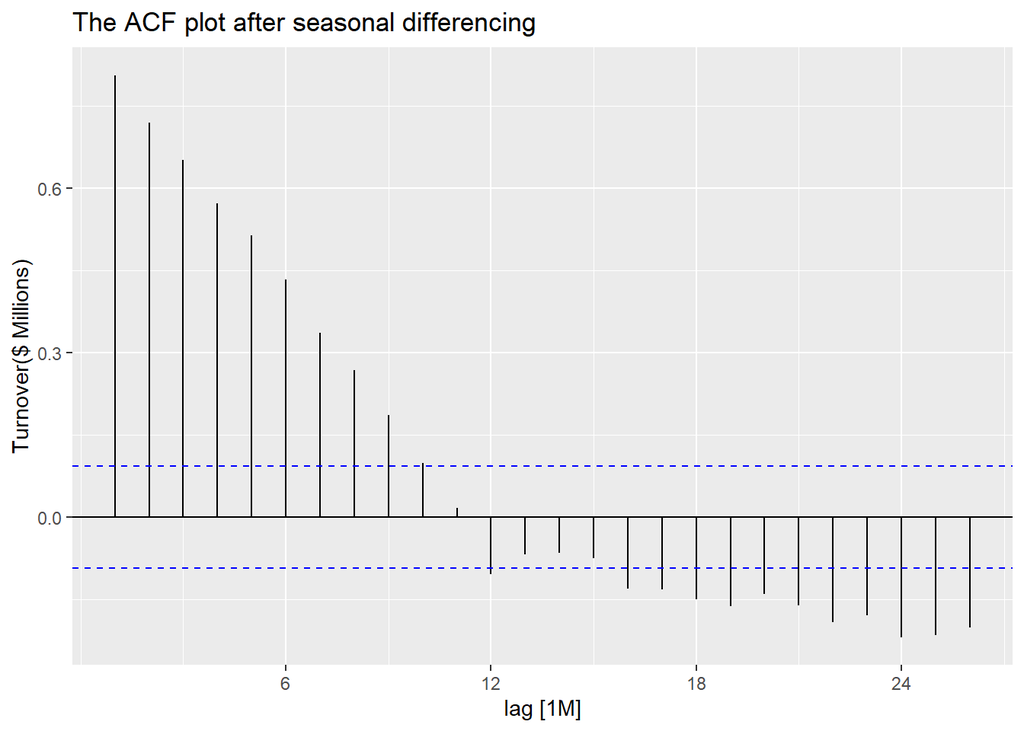

```r
# ACF
myseries %>%
  ACF(difference(box_cox(Turnover, lambda), 12)) %>%
  autoplot() +
  labs(title = "The ACF plot after seasonal differencing",
       y = "Turnover($ Millions)")
```

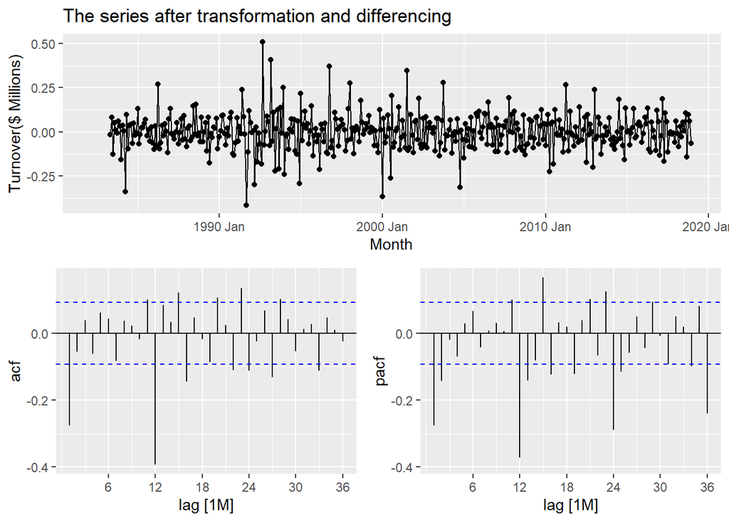

```r
# Differencing
myseries %>%
  gg_tsdisplay(difference(difference(box_cox(Turnover, lambda), 12)), plot_type = "partial", lag = 36) +
  labs(title = "The series after transformation and differencing",
       y = "Turnover($ Millions)")
```

As the series is non-stationary data, we can use the 3 steps to make it stationary. First, by box_cox transformation, we change the variance. For determining whether seasonal differencing is required, we use `unitroot_nsdiffs()` function, and `unitroot_ndiffs()` to determine ordinary differencing. Although the result of a unit-root test for ordinary differencing is 0 which indicates we do not need the last step for regular differencing, the ACF plot shows the data is still non-stationary. After the seasonally differencing which removes the seasonality (step 2), we can apply the regular differencing for the series to remove the trend and anything else. The final plot shows the stationary.

# A short-list of appropriate ARIMA models and ETS models

```r
# split into train and test data
myseries_train <- myseries %>%
  filter(year(Month) <= 2016)
myseries_test <- myseries %>%
  filter(year(Month) > 2016)
```

### ARIMA models

```r
ARIMA_fit <- myseries_train %>%
  model(
    arima011011 = ARIMA(box_cox(Turnover, lambda) ~ pdq(0,1,1) + PDQ(0,1,1)),
    arima110011 = ARIMA(box_cox(Turnover, lambda) ~ pdq(1,1,0) + PDQ(0,1,1)),
    auto = ARIMA(box_cox(Turnover, lambda),
                 stepwise = FALSE,
                 approx = FALSE)
  )

glance(ARIMA_fit) %>% arrange(AICc) %>% select(.model:BIC)
```

```
## # A tibble: 3 x 6
##   .model       sigma2 log_lik   AIC  AICc   BIC
##   <chr>         <dbl>   <dbl> <dbl> <dbl> <dbl>
## 1 auto        0.00559    469. -923. -923. -891.
## 2 arima011011 0.00579    459. -911. -911. -899.
## 3 arima110011 0.00597    453. -900. -900. -888.
```

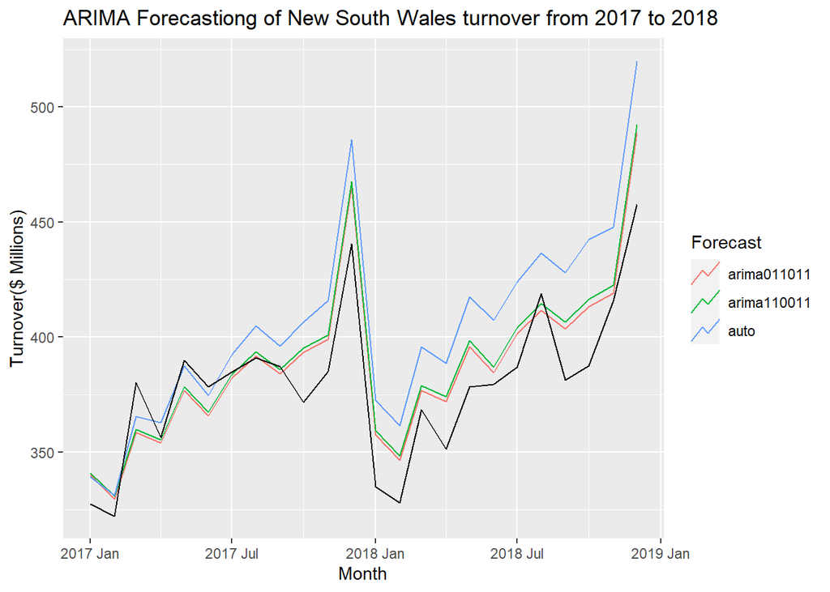

```r
forecast(ARIMA_fit, h = 24) %>%
  autoplot(myseries_test, level = NULL) +
  labs(title = "ARIMA Forecastiong of New South Wales turnover from 2017 to 2018",
       y = "Turnover($ Millions)") +
  guides(colour = guide_legend(title = "Forecast"))
```

For P and Q, there is a significant spike at lag 12 in the ACF, and decreasing spikes at lags 12, 24 and 36 in the PACF. This suggests Q=1 and P=0. For p and q, we can see the lags up to the seasonal period. So lags 1-11 can indicates there is a significant spike at lag 1 in the ACF, plus two smaller ones at 7 and 11. There is a significant spike at lags 1 and 2 in the PACF, plus a small one at 11. If we ignore the small spikes at lags 7 and 11, this looks like q=1 and p=0. So my starting point would be ARIMA(0,1,1)(0,1,1)[12]. Same with the second model choosen. We will also include an automatically selected model. By setting `stepwise=FALSE` and `approximation=FALSE`, we are making R work extra hard to find a good model.

The plot shows the forecasting of 3 ARIMA models applying to a test-set consisting of the last 24 months.

### ETS models

```r
ETS_fit <- myseries_train %>%
  model(
    multiplicative = ETS(Turnover ~ error("M") + trend("A") + season("M")),
    hw = ETS(Turnover ~ error("M") + trend("Ad") + season("M")),
    auto = ETS(Turnover)
  )

glance(ETS_fit) %>% arrange(AICc) %>% select(.model:BIC)
```

```
## # A tibble: 3 x 6
##   .model          sigma2 log_lik   AIC  AICc   BIC
##   <chr>            <dbl>   <dbl> <dbl> <dbl> <dbl>
## 1 hw             0.00236  -2077. 4190. 4192. 4263.
## 2 auto           0.00236  -2077. 4190. 4192. 4263.
## 3 multiplicative 0.00237  -2080. 4194. 4195. 4262.
```

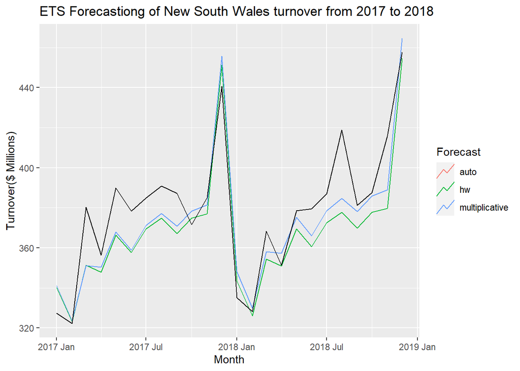

```r
forecast(ETS_fit, h = 24) %>%
  autoplot(myseries_test, level = NULL) +
  labs(title = "ETS Forecastiong of New South Wales turnover from 2017 to 2018",
       y = "Turnover($ Millions)") +
  guides(colour = guide_legend(title = "Forecast"))
```

The plot shows the forecasting of 3 ETS models applying to a test-set consisting of the last 24 months.

# One ARIMA model and one ETS model

### ARIMA model

```r
# Parameter estimates
best_ARIMA <- myseries_train %>%
  model(arima110011 = ARIMA(box_cox(Turnover, lambda) ~ pdq(0,1,1) + PDQ(0,1,1)))
report(best_ARIMA)
```

```
## Series: Turnover
## Model: ARIMA(0,1,1)(0,1,1)[12]
## Transformation: box_cox(Turnover, lambda)
##
## Coefficients:
##           ma1     sma1
##       -0.3491  -0.8933
## s.e.   0.0491   0.0313
##
## sigma^2 estimated as 0.005795:  log likelihood=458.57
## AIC=-911.15   AICc=-911.09   BIC=-899.14
```

```r
glance(best_ARIMA)
```

```
## # A tibble: 1 x 10
##   State         Indus~1 .model  sigma2 log_lik   AIC  AICc   BIC ar_ro~2 ma_ro~3
##   <chr>         <chr>   <chr>    <dbl>   <dbl> <dbl> <dbl> <dbl> <list>  <list>
## 1 New South Wa~ Pharma~ arima~ 0.00579    459. -911. -911. -899. <cpl>   <cpl>
## # ... with abbreviated variable names 1: Industry, 2: ar_roots, 3: ma_roots
```

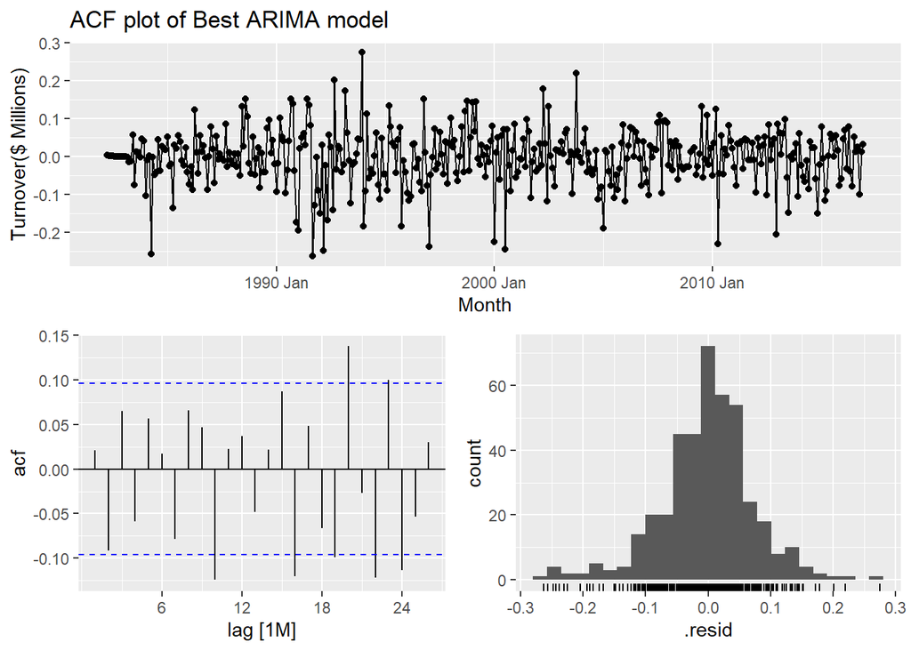

```r
# ACF plot
gg_tsresiduals(best_ARIMA) +
  labs(title = "ACF plot of Best ARIMA model",
       y = "Turnover($ Millions)")
```

```r
# Ljung-Box test
augment(best_ARIMA) %>%
  features(.innov, ljung_box, lag = 24, dof = 4)
```

```
## # A tibble: 1 x 5
##   State           Industry                                .model lb_stat lb_pv~1
##   <chr>           <chr>                                   <chr>    <dbl>   <dbl>
## 1 New South Wales Pharmaceutical, cosmetic and toiletry ~ arima~    64.7 1.28e-6
## # ... with abbreviated variable name 1: lb_pvalue
```

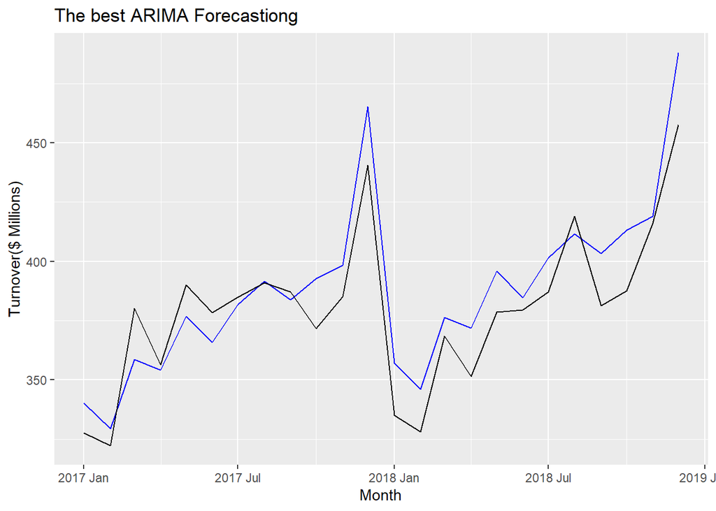

```r
# Prediction intervals
forecast(best_ARIMA, h = 24, bootstrap = TRUE) %>%
  autoplot(myseries_test, level = NULL) +
  labs(title = "The best ARIMA Forecastiong",
       y = "Turnover($ Millions)")
```

### ETS model

```r
# Parameter estimates
best_ETS <- myseries_train %>%
  model(hw = ETS(Turnover ~ error("M") + trend("Ad") + season("M")))
report(best_ETS)
```

```
## Series: Turnover
## Model: ETS(M,Ad,M)
##   Smoothing parameters:
##     alpha = 0.5944558
##     beta  = 0.01110088
##     gamma = 0.0001034853
##     phi   = 0.9799701
##
##   Initial states:
##      l[0]      b[0]      s[0]     s[-1]     s[-2]    s[-3]    s[-4]    s[-5]
##  41.95522 0.5186482 0.9605474 0.8841827 0.9318839 1.225624 1.024405 1.019492
##      s[-6]    s[-7]    s[-8]     s[-9]  s[-10]    s[-11]
##  0.9991811 1.020878 1.007214 0.9757492 1.00018 0.9506628
##
##   sigma^2:  0.0024
##
##      AIC     AICc      BIC
## 4190.469 4192.188 4263.065
```

```r
glance(best_ETS)
```

```
## # A tibble: 1 x 11
##   State      Indus~1 .model  sigma2 log_lik   AIC  AICc   BIC   MSE  AMSE    MAE
##   <chr>      <chr>   <chr>    <dbl>   <dbl> <dbl> <dbl> <dbl> <dbl> <dbl>  <dbl>
## 1 New South~ Pharma~ hw     0.00236  -2077. 4190. 4192. 4263.  77.2  103. 0.0358
## # ... with abbreviated variable name 1: Industry
```

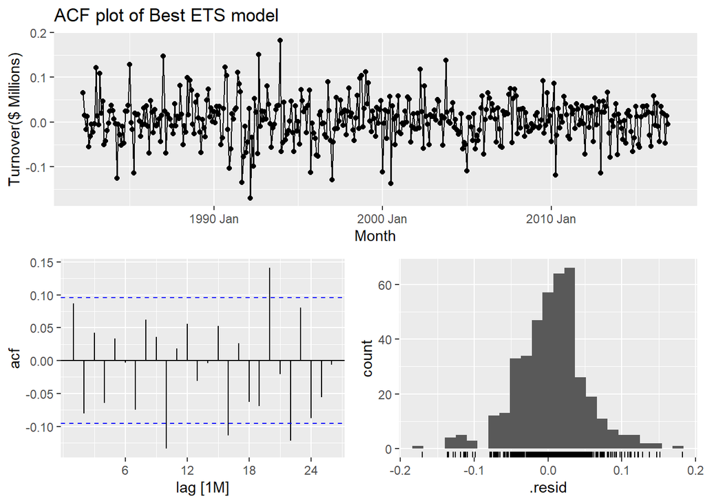

```r
# ACF plot
gg_tsresiduals(best_ETS)+
  labs(title = "ACF plot of Best ETS model",
       y = "Turnover($ Millions)")
```

```r
# Ljung-Box test
augment(best_ETS) %>%
  features(.innov, ljung_box, lag = 24, dof = 4)
```

```
## # A tibble: 1 x 5
##   State           Industry                                .model lb_stat lb_pv~1
##   <chr>           <chr>                                   <chr>    <dbl>   <dbl>
## 1 New South Wales Pharmaceutical, cosmetic and toiletry ~ hw        55.9 3.05e-5
## # ... with abbreviated variable name 1: lb_pvalue
```

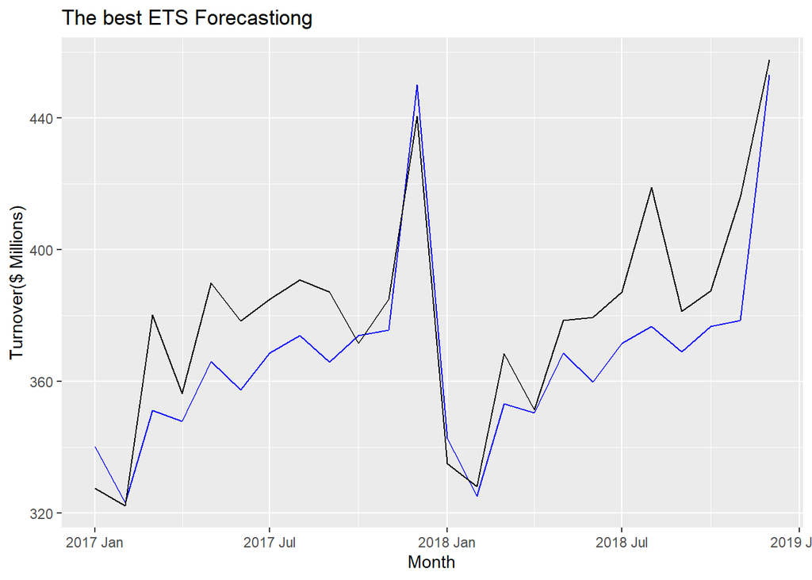

```r
# Prediction intervals
forecast(best_ETS, h = 24, bootstrap = TRUE) %>%
  autoplot(myseries_test, level = NULL) +
  labs(title = "The best ETS Forecastiong",
       y = "Turnover($ Millions)")
```

# ARIMA vs ETS

```r
bind_rows(
    best_ARIMA %>% accuracy(),
    best_ETS %>% accuracy(),
    best_ARIMA %>% forecast(h = 24) %>% accuracy(myseries_test),
    best_ETS %>% forecast(h = 24) %>% accuracy(myseries_test)
  ) %>%
  select(-ME, -MPE, -ACF1)
```

```
## # A tibble: 4 x 9
##   State           Industry        .model .type  RMSE   MAE  MAPE    MASE   RMSSE
##   <chr>           <chr>           <chr>  <chr> <dbl> <dbl> <dbl>   <dbl>   <dbl>
## 1 New South Wales Pharmaceutical~ arima~ Trai~  8.94  6.16  3.54   0.366   0.417
## 2 New South Wales Pharmaceutical~ hw     Trai~  8.79  6.14  3.56   0.365   0.410
## 3 New South Wales Pharmaceutical~ arima~ Test  16.3  13.9   3.66 NaN     NaN
## 4 New South Wales Pharmaceutical~ hw     Test  17.5  14.1   3.64 NaN     NaN
```

# Full data forecasting

### ARIMA model

```r
ARIMA_fit_all <- myseries %>%
  model(ARIMA = ARIMA(box_cox(Turnover, lambda) ~ pdq(1,1,0) + PDQ(0,1,1)))
report(ARIMA_fit_all)
```

```
## Series: Turnover
## Model: ARIMA(1,1,0)(0,1,1)[12]
## Transformation: box_cox(Turnover, lambda)
##
## Coefficients:
##           ar1     sma1
##       -0.2731  -0.8833
## s.e.   0.0465   0.0286
##
## sigma^2 estimated as 0.005828:  log likelihood=485.63
## AIC=-965.27   AICc=-965.21   BIC=-953.09
```

```r
ARIMA_fit_all %>%
  forecast(h = 24, point_forecast = lst(mean, median)) %>%
  hilo(level = 80)
```

```
## # A tsibble: 24 x 8 [1M]
## # Key:       State, Industry, .model [1]
##    State           Industry       .model    Month          Turnover  mean median
##    <chr>           <chr>          <chr>     <mth>            <dist> <dbl>  <dbl>
##  1 New South Wales Pharmaceutica~ ARIMA  2019 Jan t(N(7.7, 0.0058))  355.   355.
##  2 New South Wales Pharmaceutica~ ARIMA  2019 Feb t(N(7.6, 0.0089))  344.   343.
##  3 New South Wales Pharmaceutica~ ARIMA  2019 Mar  t(N(7.8, 0.013))  379.   378.
##  4 New South Wales Pharmaceutica~ ARIMA  2019 Apr  t(N(7.8, 0.016))  370.   370.
##  5 New South Wales Pharmaceutica~ ARIMA  2019 May   t(N(7.9, 0.02))  396.   395.
##  6 New South Wales Pharmaceutica~ ARIMA  2019 Jun  t(N(7.8, 0.023))  386.   385.
##  7 New South Wales Pharmaceutica~ ARIMA  2019 Jul  t(N(7.9, 0.027))  401.   399.
##  8 New South Wales Pharmaceutica~ ARIMA  2019 Aug  t(N(7.9, 0.031))  414.   412.
##  9 New South Wales Pharmaceutica~ ARIMA  2019 Sep  t(N(7.9, 0.034))  403.   400.
## 10 New South Wales Pharmaceutica~ ARIMA  2019 Oct  t(N(7.9, 0.038))  409.   407.
## # ... with 14 more rows, and 1 more variable: `80%` <hilo>
```

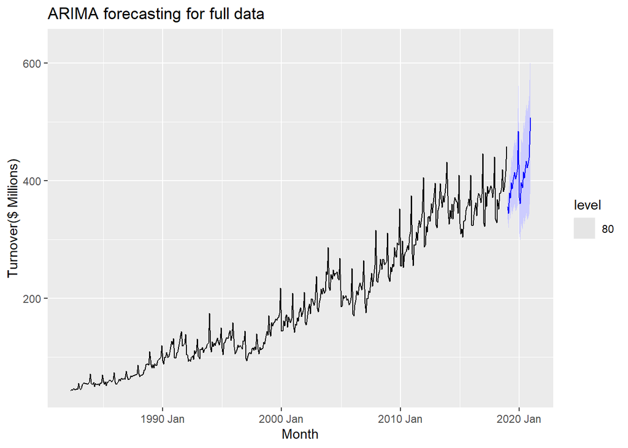

```r
 ARIMA_fit_all %>%
  forecast(h = 24) %>%
  autoplot(myseries, level = 80) +
  labs(title = "ARIMA forecasting for full data",
       y = "Turnover($ Millions)")
```

### ETS model

```r
ETS_fit_all <- myseries %>%
  model(ETS = ETS(Turnover ~ error("M") + trend("Ad") + season("M")))
report(ETS_fit_all)
```

```
## Series: Turnover
## Model: ETS(M,Ad,M)
##   Smoothing parameters:
##     alpha = 0.578615
##     beta  = 0.01376979
##     gamma = 0.0004686979
##     phi   = 0.9799637
##
##   Initial states:
##      l[0]      b[0]      s[0]     s[-1]     s[-2]   s[-3]    s[-4]    s[-5]
##  41.90022 0.6960666 0.9627924 0.8824104 0.9296272 1.21968 1.032373 1.019583
##     s[-6]    s[-7]    s[-8]     s[-9]    s[-10]    s[-11]
##  1.000695 1.021219 1.009137 0.9742682 0.9977716 0.9504433
##
##   sigma^2:  0.0023
##
##      AIC     AICc      BIC
## 4490.618 4492.238 4564.220
```

```r
ETS_fit_all %>%
  forecast(h = 24, point_forecast = lst(mean, median)) %>%
  hilo(level = 80)
```

```
## # A tsibble: 24 x 8 [1M]
## # Key:       State, Industry, .model [1]
##    State           Industry            .model    Month     Turnover  mean median
##    <chr>           <chr>               <chr>     <mth>       <dist> <dbl>  <dbl>
##  1 New South Wales Pharmaceutical, co~ ETS    2019 Jan  N(357, 294)  357.   357.
##  2 New South Wales Pharmaceutical, co~ ETS    2019 Feb  N(339, 359)  339.   339.
##  3 New South Wales Pharmaceutical, co~ ETS    2019 Mar  N(371, 544)  371.   371.
##  4 New South Wales Pharmaceutical, co~ ETS    2019 Apr  N(366, 650)  366.   366.
##  5 New South Wales Pharmaceutical, co~ ETS    2019 May  N(385, 854)  385.   385.
##  6 New South Wales Pharmaceutical, co~ ETS    2019 Jun  N(376, 950)  376.   376.
##  7 New South Wales Pharmaceutical, co~ ETS    2019 Jul N(390, 1172)  390.   390.
##  8 New South Wales Pharmaceutical, co~ ETS    2019 Aug N(395, 1363)  395.   395.
##  9 New South Wales Pharmaceutical, co~ ETS    2019 Sep N(387, 1470)  387.   387.
## 10 New South Wales Pharmaceutical, co~ ETS    2019 Oct N(395, 1700)  395.   395.
## # ... with 14 more rows, and 1 more variable: `80%` <hilo>
```

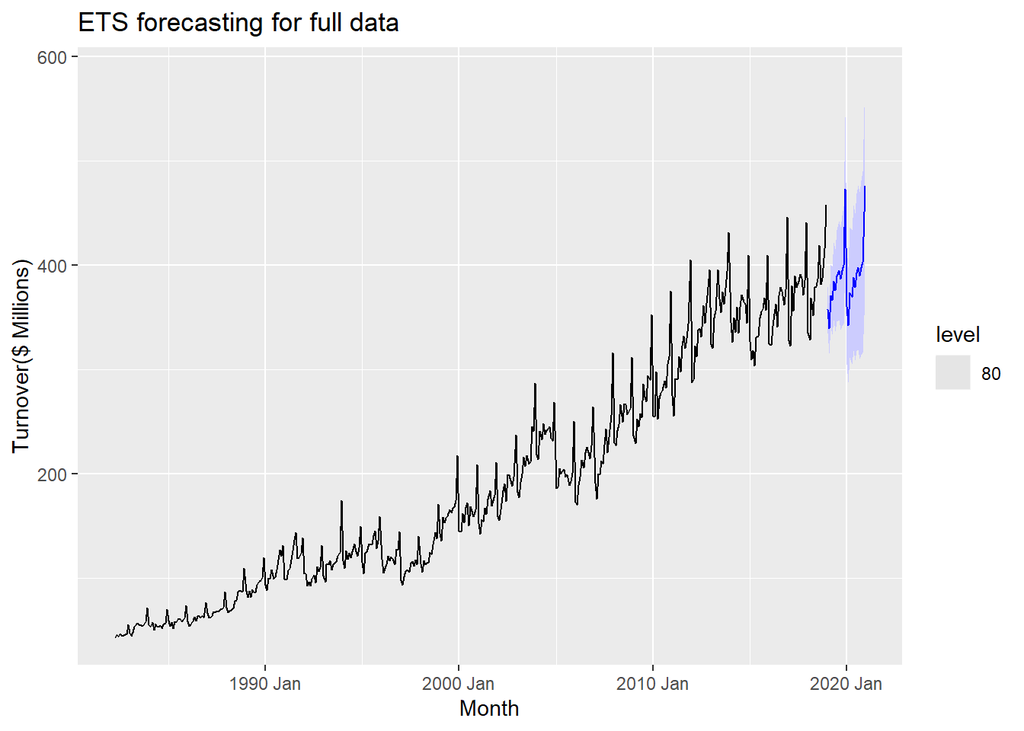

```r
ETS_fit_all %>%
  forecast(h = 24) %>%
  autoplot(myseries, level = 80)+
  labs(title = "ETS forecasting for full data",
       y = "Turnover($ Millions)")
```

# Comparision with ABS data

```r
updated_data <- readxl::read_excel("ABSdata.xls",
                                   sheet = "Data1",
                                   skip = 9) %>%
  select(Month = `Series ID`, Turnover = myseries$`Series ID`[1]) %>%
  mutate(
    Month = yearmonth(Month),
    State = myseries$State[1],
    Industry = myseries$Industry[1]
  ) %>%
  as_tsibble(index = Month, key = c(State, Industry))
```

### ARIMA model

```r
# Residual diagnostics
augment(ARIMA_fit_all) %>%
  features(.innov, ljung_box, lag = 24, dof = 4)
```

```
## # A tibble: 1 x 5
##   State           Industry                               .model lb_stat lb_pva~1
##   <chr>           <chr>                                  <chr>    <dbl>    <dbl>
## 1 New South Wales Pharmaceutical, cosmetic and toiletry~ ARIMA     98.0 2.86e-12
## # ... with abbreviated variable name 1: lb_pvalue
```

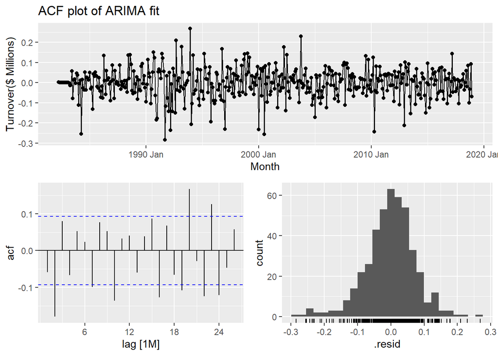

```r
gg_tsresiduals(ARIMA_fit_all) +
  labs(title = "ACF plot of ARIMA fit",
       y = "Turnover($ Millions)")
```

```r
# Accuracy
ARIMA_fit_all %>% forecast(h = 24) %>% accuracy(updated_data)
```

```
## # A tibble: 1 x 12
##   .model State    Indus~1 .type    ME  RMSE   MAE   MPE  MAPE  MASE RMSSE   ACF1
##   <chr>  <chr>    <chr>   <chr> <dbl> <dbl> <dbl> <dbl> <dbl> <dbl> <dbl>  <dbl>
## 1 ARIMA  New Sou~ Pharma~ Test   11.8  26.5  16.6  2.42  3.70 0.995  1.25 -0.140
## # ... with abbreviated variable name 1: Industry
```

### ETS model

```r
# Residual diagnostics
augment(ETS_fit_all) %>%
  features(.innov, ljung_box, lag = 24, dof = 4)
```

```
## # A tibble: 1 x 5
##   State           Industry                                .model lb_stat lb_pv~1
##   <chr>           <chr>                                   <chr>    <dbl>   <dbl>
## 1 New South Wales Pharmaceutical, cosmetic and toiletry ~ ETS       58.6 1.18e-5
## # ... with abbreviated variable name 1: lb_pvalue
```

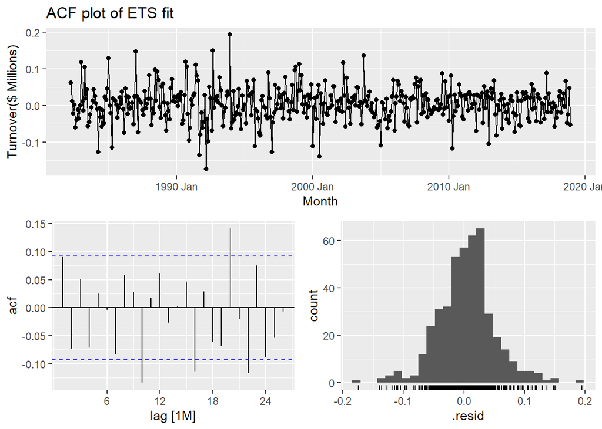

```r
gg_tsresiduals(ETS_fit_all)+
  labs(title = "ACF plot of ETS fit",
       y = "Turnover($ Millions)")
```

```r
# Accuracy
ETS_fit_all %>% forecast(h = 24) %>% accuracy(updated_data)
```

```
## # A tibble: 1 x 12
##   .model State     Indus~1 .type    ME  RMSE   MAE   MPE  MAPE  MASE RMSSE  ACF1
##   <chr>  <chr>     <chr>   <chr> <dbl> <dbl> <dbl> <dbl> <dbl> <dbl> <dbl> <dbl>
## 1 ETS    New Sout~ Pharma~ Test   30.3  42.3  31.9  6.71  7.18  1.92  1.99 0.156
## # ... with abbreviated variable name 1: Industry
```

### Forecasting plots

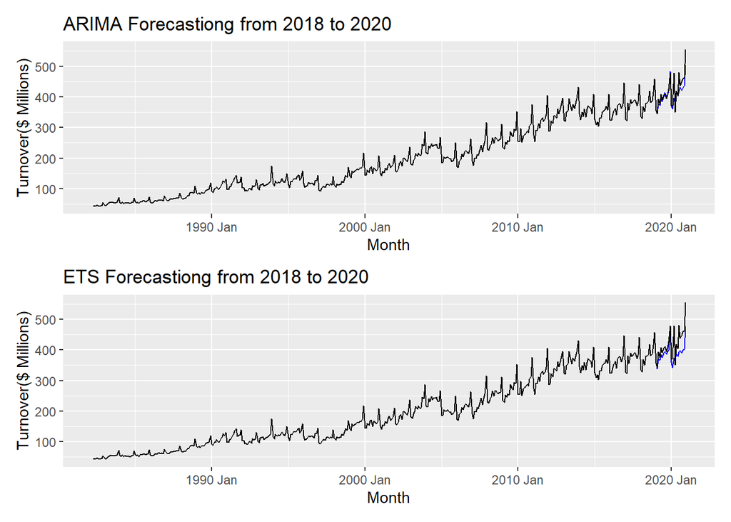

```r
p5 <- forecast(ARIMA_fit_all, h = 24, bootstrap = TRUE) %>%
  autoplot(updated_data, level = NULL) +
  labs(title = "ARIMA Forecastiong from 2018 to 2020",
       y = "Turnover($ Millions)")

p6 <- forecast(ETS_fit_all, h = 24, bootstrap = TRUE) %>%
  autoplot(updated_data, level = NULL) +
  labs(title = "ETS Forecastiong from 2018 to 2020",
       y = "Turnover($ Millions)")

p5/p6
```

By performing residual diagnostics, calculating accuracy, and plotting prediction images for ARIMA and ETS models respectively, we can first see from the histogram that the residual of the ARIMA model shows a more normal distribution, while the ETS model is slightly right-skewed. The accuracy is also a significant advantage of ARIMA fit. Finally, We can also see from the plot of forecasting that the ARIMA model’s predictions are more consistent with the actual data.

# Benefits and limitations

For the ARIMA model,

- Benefit: ARIMA model is relatively robust against outliers and missing data, as they are designed to handle irregularities in the time series.
- Limitation: As we can see from the Ljung_box test of the ARIMA model applying for updated data, the result is significant (i.e. the p-value is less than 0.05), which means the residuals appear not to be white noise. That may infect the prediction. Besides, due to the iterative nature of the parameter estimation process, it may take a longer time to calculate for the ARIMA model if the dataset is larger.

On the other hand, for the ETS model,

- Benefit: ETS model is well-suited for forecasting time series with strong seasonal patterns, no matter additive or multiplicative seasonal components.
- Limitation: ETS model does not enforce stationary on the time series data, While explicit differencing or transformations may be required for better results. As well as the same limitation as the ARIMA model, the Ljung_box test output indicates the residuals appear not to be white noise.